# Practical Machine Learning Assignment

Mary0523

September 19, 2018

### Project goal

The goal of this project is to predict the manner in which people did barbell lifts. This is the “classe” variable in the training set. May use any of the other variables to predict with.  
Use the prediction model to predict 20 different test cases.

### Download training dataset

```r
url<-"https://d396qusza40orc.cloudfront.net/predmachlearn/pml-training.csv"
download.file(url,destfile ="C:/Users/may/Desktop/DataScience/Practical_Machine_Learning/Project/pml-training.csv")
pml_training<-read.csv("C:/Users/may/Desktop/DataScience/Practical_Machine_Learning/Project/pml-training.csv")
```

### Cross validation by further divide the training dataset into subtraining(70%) and subtesting(30%) dataset

```r
library(caret)
set.seed(12345)
inTrain<-createDataPartition(y=pml_training$classe,p=0.7,list=F)
subtraining<-pml_training[inTrain,]
subtesting<-pml_training[-inTrain,]
```

### Data cleaning for subtraining and subtesting dataset

```r
#remove the first 7 columns which are not variables can be used to predict classe
subtraining<-subset(subtraining,select=-c(1,2,3,4,5,6,7))
#After check each variables by str() function (not show up here) we found several variables contains NA only.
#So delete those variables
subtraining<-subset(subtraining,select=c(colSums(is.na(subtraining))==0))
#Check near zero variance
NZV<-nearZeroVar(subtraining, saveMetrics=T)
#Delete variable with nzv=T
subtraining<-subtraining[,!NZV$nzv]

subtesting<-subset(subtesting,select=-c(1,2,3,4,5,6,7))
subtesting<-subset(subtesting,select=c(colSums(is.na(subtesting))==0))
subtesting<-subtesting[,!NZV$nzv]
```

### Prediction models

Predicting with decision tree: use a sample prediction model first

```r
set.seed(12345)
modFit<-train(classe~.,method="rpart",data=subtraining)
library(rattle)
```

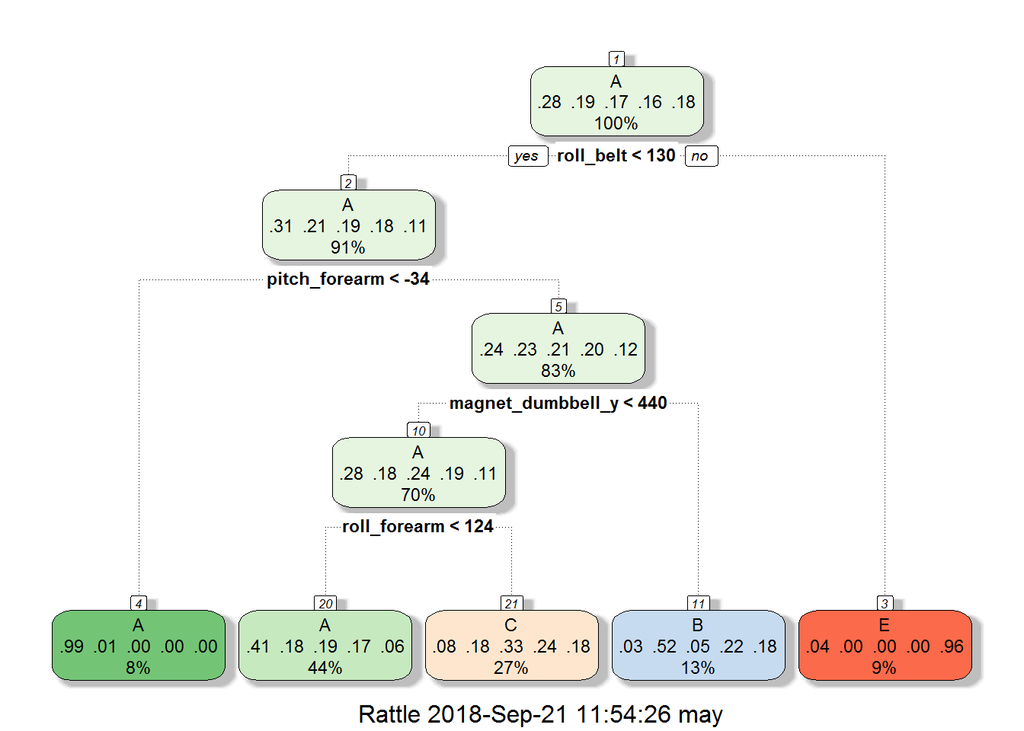

```r
fancyRpartPlot(modFit$finalModel)
```

```r
pred<-predict(modFit,newdata=subtesting)
#Accuracy of the model
confusionMatrix(pred,subtesting$classe)$overall['Accuracy']
```

```
##  Accuracy
## 0.4963466
```

The decision tree is esay to interpret but this method could not have pruning or cross-validation which can lead to overfitting and the model can not estimate uncertainty well and its results may be variable.  
From out results we can see the overall accuracy is 0.4963466, which is not very good.

Predict with more advanced models  
Predicting with random forests  
The default “rf” method runs very slow so use method in:  
https://github.com/lgreski/datasciencectacontent/blob/master/markdown/pml-randomForestPerformance.md

```r
set.seed(12345)
#Step 1: Configure parallel processing
library(parallel)
library(doParallel)
cluster <- makeCluster(detectCores() - 1)
registerDoParallel(cluster)
#Step 2: Configure trainControl object
fitControl <- trainControl(method = "cv",
                           number = 5,
                           allowParallel = TRUE)
#Step 3: Develop training model
modFit_rf <- train(classe~., method="rf",data=subtraining,trControl = fitControl)
#Step 4: De-register parallel processing cluster
stopCluster(cluster)
registerDoSEQ()

pred_rf<-predict(modFit_rf,newdata=subtesting)
#Accuracy of the model
confusionMatrix(pred_rf,subtesting$classe)$overall['Accuracy']
```

```
##  Accuracy
## 0.9891249
```

Predicting with boosting

```r
set.seed(12345)
modFit_gbm<-train(classe~.,method="gbm",data=subtraining,verbose=FALSE)
pred_gbm<-predict(modFit_gbm,newdata=subtesting)
#Accuracy of the model
confusionMatrix(pred_gbm,subtesting$classe)$overall['Accuracy']
```

```
##  Accuracy
## 0.9575191
```

The accuracy of this model is 0.9575191, worse than random forest

Combining predictors (random forest and boosting)

```r
predcomb<-data.frame(pred_rf,pred_gbm,classe=subtesting$classe)
combModFit<-train(classe~.,method="rf",data=predcomb)
combPred<-predict(combModFit,newdata=predcomb)
#Accuracy of the model
confusionMatrix(combPred,subtesting$classe)$overall['Accuracy']
```

```
##  Accuracy
## 0.9891249
```

The accutacy of the combined model is 0.9891249, the same as random forest. So use random forest as the final prediction model.

### Download testing dataset and apply random forest prediction on testing dataset

```r
url<-"https://d396qusza40orc.cloudfront.net/predmachlearn/pml-testing.csv"
download.file(url,destfile ="C:/Users/may/Desktop/DataScience/Practical_Machine_Learning/Project/pml-testing.csv")
pml_testing<-read.csv("C:/Users/may/Desktop/DataScience/Practical_Machine_Learning/Project/pml-testing.csv")

pml_testing<-as.data.frame(pml_testing)

final_pred<-predict(modFit_rf,newdata=pml_testing)
final_pred
```

```
##  [1] B A B A A E D B A A B C B A E E A B B B
## Levels: A B C D E
```

```r
pml_testing$pred_classe<-as.factor(final_pred)
```